# Leveraging Artificial Intelligence in Modern Biomarker-Driven Clinical Trial Design: the ARPA-H ADAPT Program

Naim Rashid, PhD

Department of Biostatistics  
UNC Gillings School of Global Public Health  
& Lineberger Comprehensive Cancer Center

2026-02-05

# Part 1: The Problem & ADAPT

## Metastatic Cancer: Incremental Progress

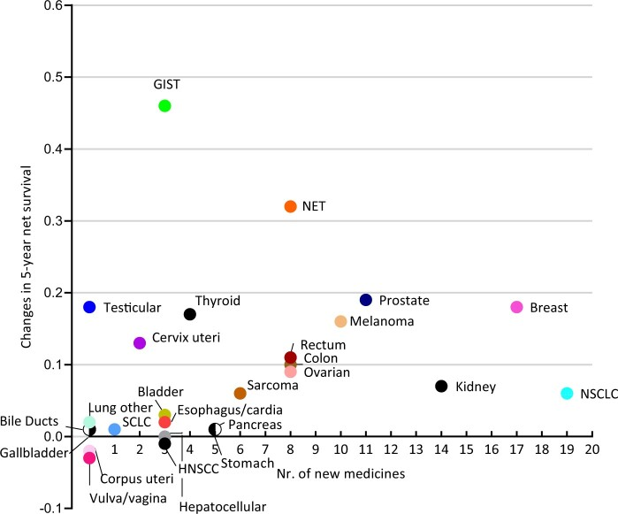

Luyendijk M et al. JNCI 2023

**Despite Precision Oncology Advances**

- Metastatic cancer remains a leading cause of death
- Survival gains have been modest
- New medicines approved, but 5-year survival gains incremental

*Despite more drugs, we haven’t fundamentally changed how trials learn.*

**Question:** Why aren’t we seeing bigger gains?

## Resistance: A Dynamic Process

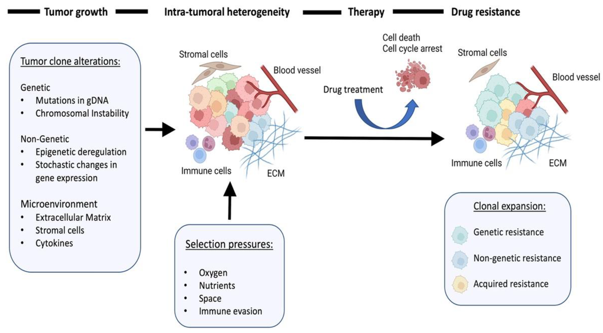

Karagiannis D, Rampias T. Cancers 2022

**Resistance Mechanisms Emerge Over Time**

- ESR1 mutations, PI3K pathway activation
- Tumor microenvironment remodeling
- Clonal evolution escapes initial therapy

**Traditional trials fail to capture this**

- Fixed regimens miss interception
- Baseline-only biomarkers can’t track evolution

## Clinical Consequence: Delayed Intervention

**Current Standard of Care**

- Treatment decisions fixed at baseline
- Response assessed at predefined intervals
- Course correction only after clinical progression

**Result: Patients may remain on ineffective therapy while resistance mechanisms consolidate**

**What Patients Need**

- Earlier detection of treatment failure
- Biomarker-guided therapy adaptation
- Trials designed to learn during treatment

**ADAPT Goal:** Enable real-time treatment optimization based on evolving tumor biology

## The Opportunity: ARPA-H ADAPT

[figure not shown]

March 2024: ARPA-H launches ADAPT program to address these gaps

**Gaps in Current Trials**

| Gap | Current → Needed |
| --- | --- |
| **Design** | Fixed → Adaptive |
| **Biomarkers** | Baseline → Continuous |
| **Infrastructure** | Retrospective → Real-time |
| **Translation** | Siloed → Embedded |

## ADAPT Goal: Dynamic Biomarkers

[figure not shown]

## ADAPT: Three Technical Areas

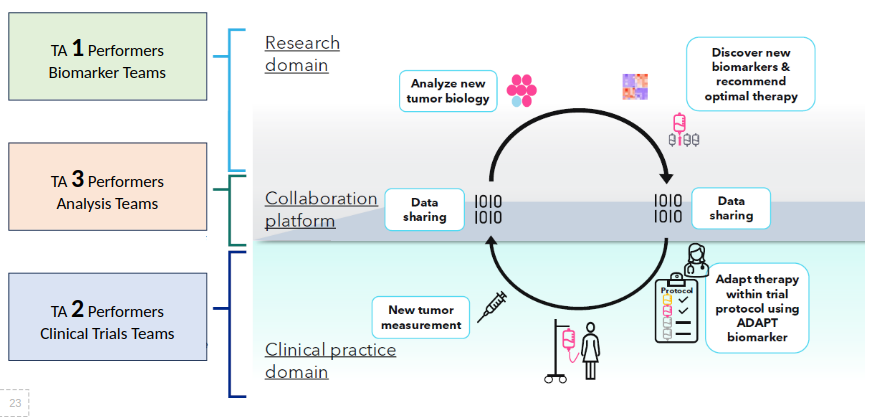

## MBC TA2 Team: TBCRC EVOLVE-BDT

[figure not shown]

## TBCRC EVOLVE-BDT: Our Trial

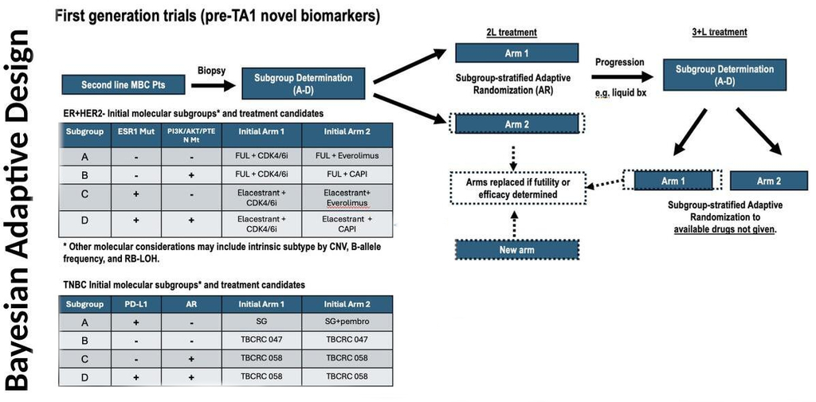

**EVOLVE-BDT: A Biomarker-Stratified Platform**

- **Population:** 2L metastatic breast cancer (ER+/HER2- and TNBC)
- **Biomarker stratification:** Patients matched to subtrials by molecular profile
- **Resistance monitoring:** Serial tumor and blood collection
- **TA1 integration:** New arms added to test proposed resistance targets

Bayesian adaptive design enables early stopping + continuous learning (~700 patients)

## Why Bayesian Adaptive Design?

**Traditional vs Adaptive**

| Aspect | Fixed | Adaptive |
| --- | --- | --- |
| Enrollment | All pts | Stop early |
| Analysis | End only | Continuous |
| Arms | Static | Add/drop |
| Savings | None | 30-50% |

**Enables:** Early futility/efficacy stopping, adaptive randomization, biomarker-driven arm selection

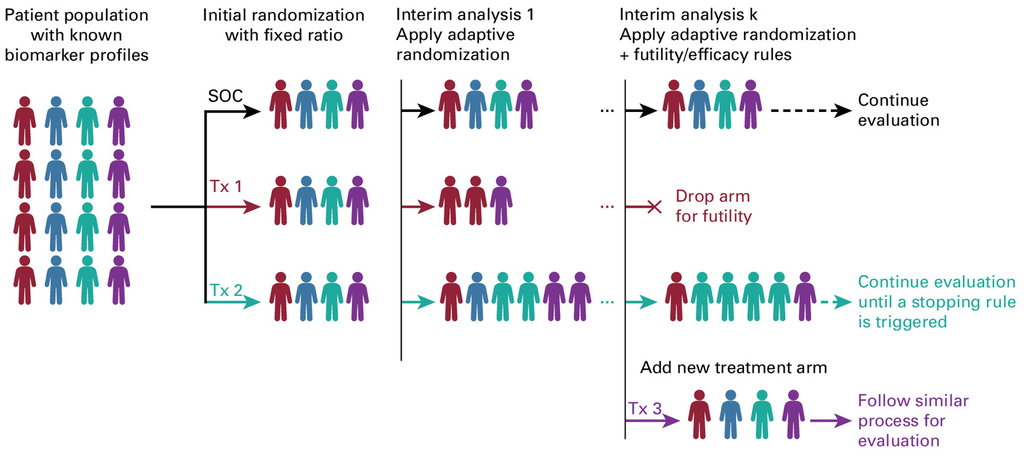

## What This Means for Your Patients

**Traditional Fixed Trial**

*Mrs. Johnson, 58, ER+/HER2-, ESR1 mutation*

- Enrolls in standard Phase II (2L MBC)
- Trial enrolls all **65 patients** before analysis
- Takes **32 months** to reach enrollment target
- Ineffective arm discovered only at study end

**EVOLVE-BDT Adaptive Trial**

*Mrs. Johnson, 58, ER+/HER2-, ESR1 mutation*

- Enrolls in biomarker-matched sub-trial
- Interim analyses after **15 PFS events** accumulate
- **92% chance** of early futility stop if ineffective
- Expected enrollment: **~46 patients** vs 65

**Bottom line:** 19 fewer patients on ineffective therapy. Answers months sooner.

## The Design Challenge

Once we established the scientific framework, we encountered a fundamental obstacle:

> **We could design the science. We could not design the trial.**

Bayesian adaptive trials require 8+ interacting parameters—efficacy thresholds, futility boundaries, interim timing, sample size constraints—each affecting regulatory compliance and patient outcomes.

**Manual calibration proved intractable:** weeks of iteration, inconsistent results across statisticians, no guarantee of optimality.

*We needed a systematic approach to navigate this complexity.*

# Part 2: BATON - AI-Powered Calibration

## The Calibration Challenge: Four Competing Goals

Designing adaptive trials requires achieving ALL FOUR simultaneously

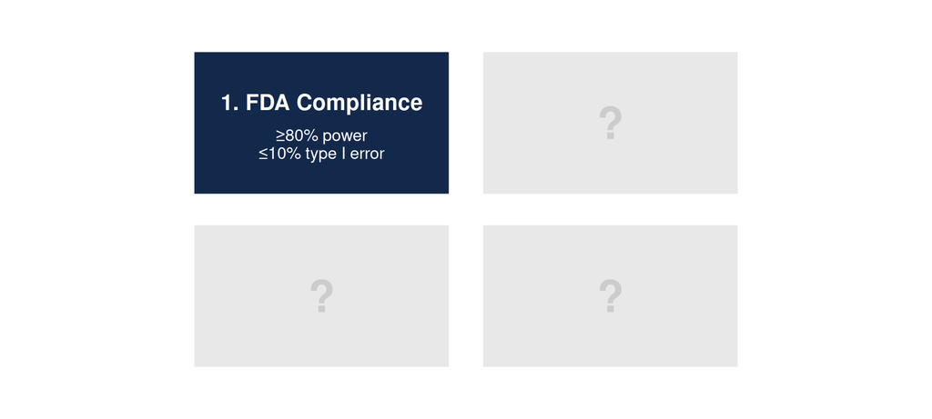

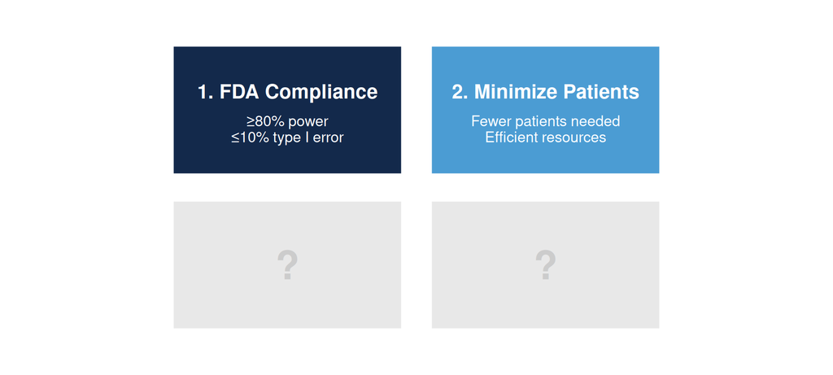

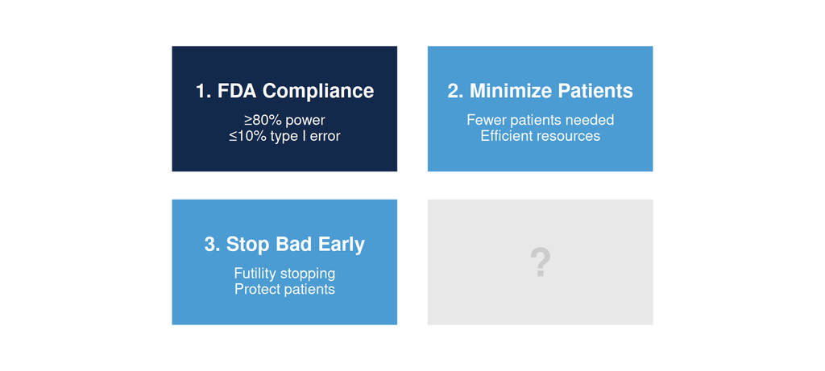

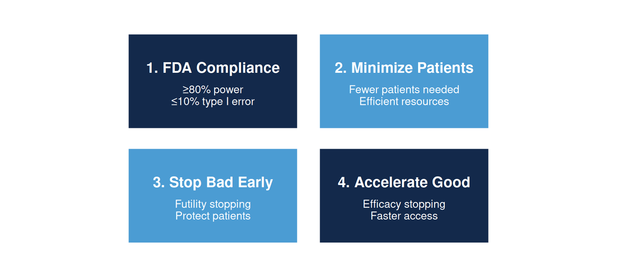

Out of 1,000 possible designs, only ~70 satisfy all four requirements → AI finds the needle in the haystack

## BATON: Intelligent Search Through Design Space

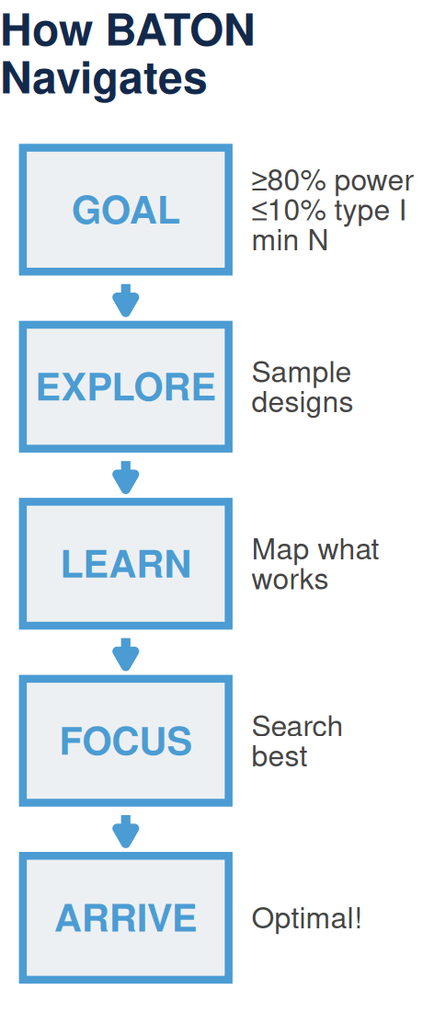

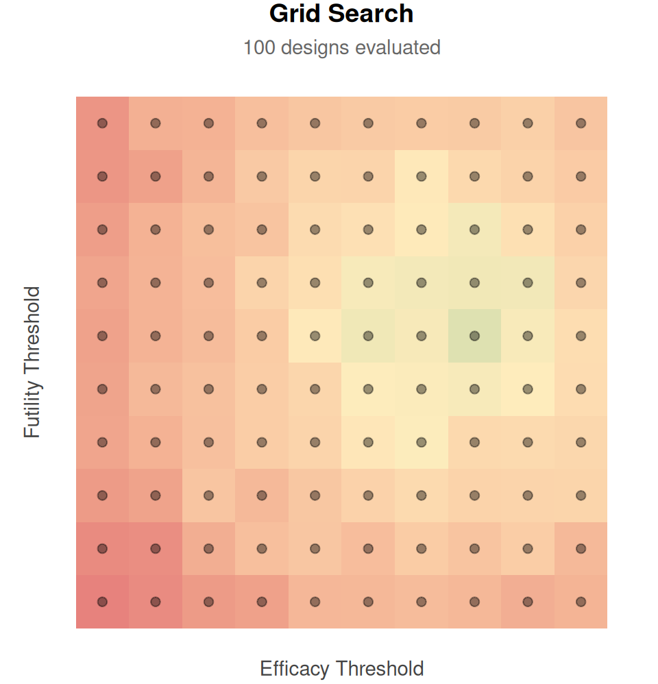

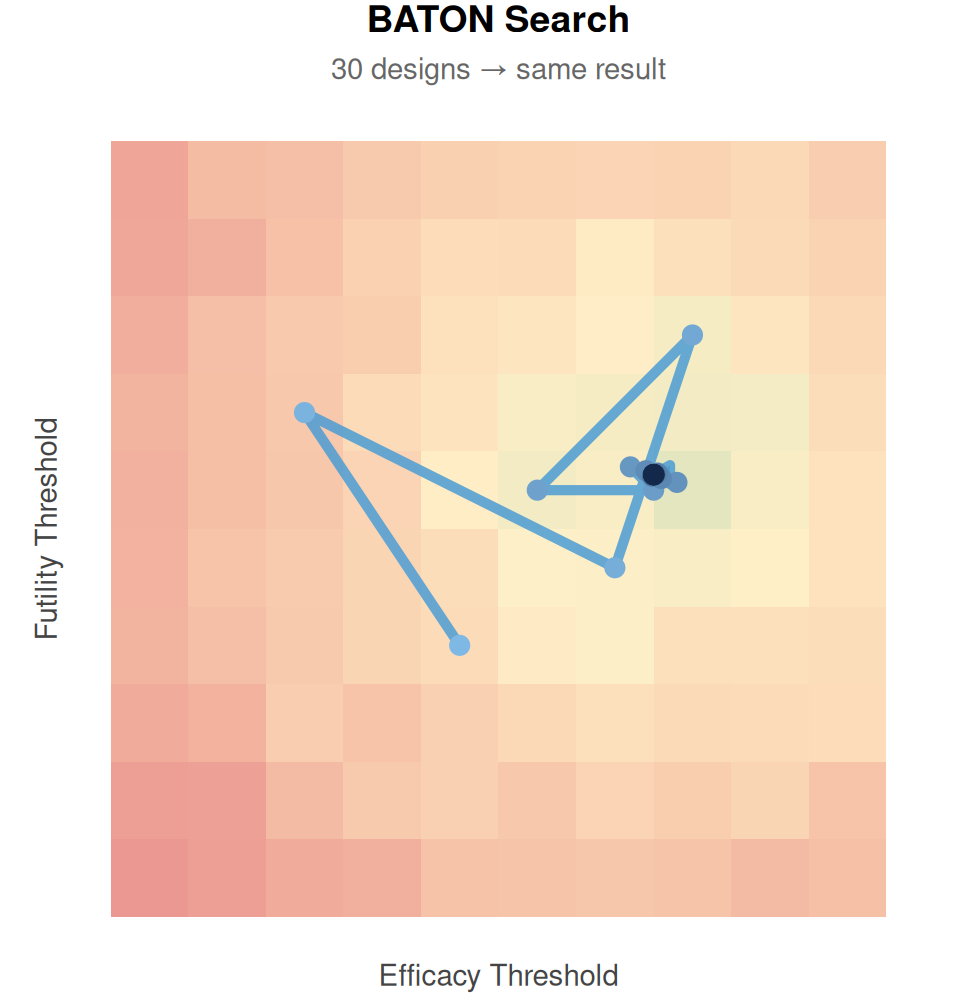

**70% fewer evaluations** — minutes instead of days

## Traditional Calibration vs BATON

**Manual Approach**

| Aspect | Limitation |
| --- | --- |
| Process | Trial-and-error |
| Duration | Days to weeks |
| Scope | One at a time |
| Reproducibility | Person-dependent |
| Documentation | Often incomplete |
| Regulatory risk | Variable |

**BATON Approach**

| Aspect | Capability |
| --- | --- |
| Process | Systematic |
| Duration | Minutes to hours |
| Scope | 1000s evaluated |
| Reproducibility | Deterministic |
| Documentation | Full audit trail |
| Regulatory risk | Documented |

Designs that would have taken months to discover—or never been found at all

BATON = **B**ayesian **A**daptive **T**rial **O**ptimizatio**N** — uses Bayesian optimization to efficiently search complex design spaces

## BATON: Fewer Patients, FDA-Compliant Designs

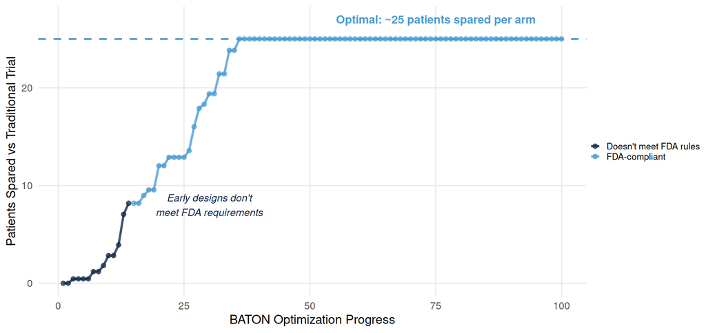

**Bottom line:** BATON finds designs that spare ~25 patients/arm from ineffective treatment

Each point = one candidate design evaluated (~5,000 simulated trials per design)

## An Unexpected Finding

BATON revealed a hidden trade-off with real patient consequences:

> **Minimizing enrollment caps can prevent patients from learning sooner that their treatment works.**

Caps set too low sacrifice early success declarations—patients wait longer for answers.

**Why this matters:** BATON surfaced this *before* launch, recommending a slightly higher cap that preserves early efficacy stopping while still protecting against futility.

# Summary

## The Big Picture: Real Impact

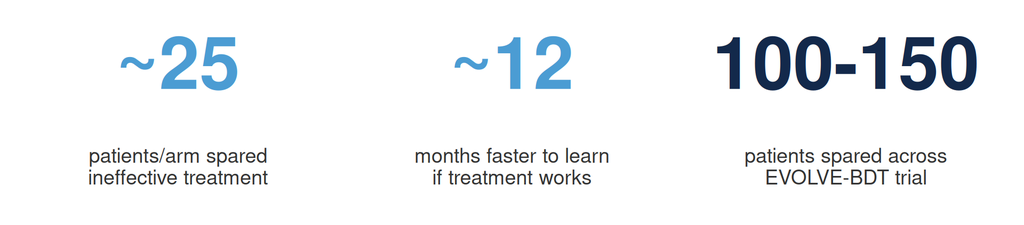

**Design calibration:** minutes, not days | **Documentation:** complete FDA audit trail | **Reproducibility:** 100%

## Key Takeaways

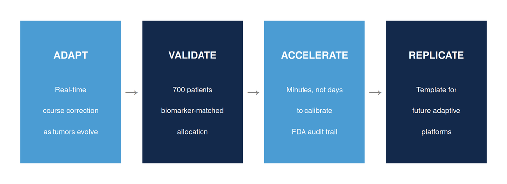

## Thanks to Our Team and Funders

**Resources**

- `BATON` R package
- `evolveTrial` R package
- Manuscript in prep

**Contact**

[figure not shown]

naim@unc.edu

[figure not shown]

EVOLVE-BDT: A True Testament to Team (Data) Science